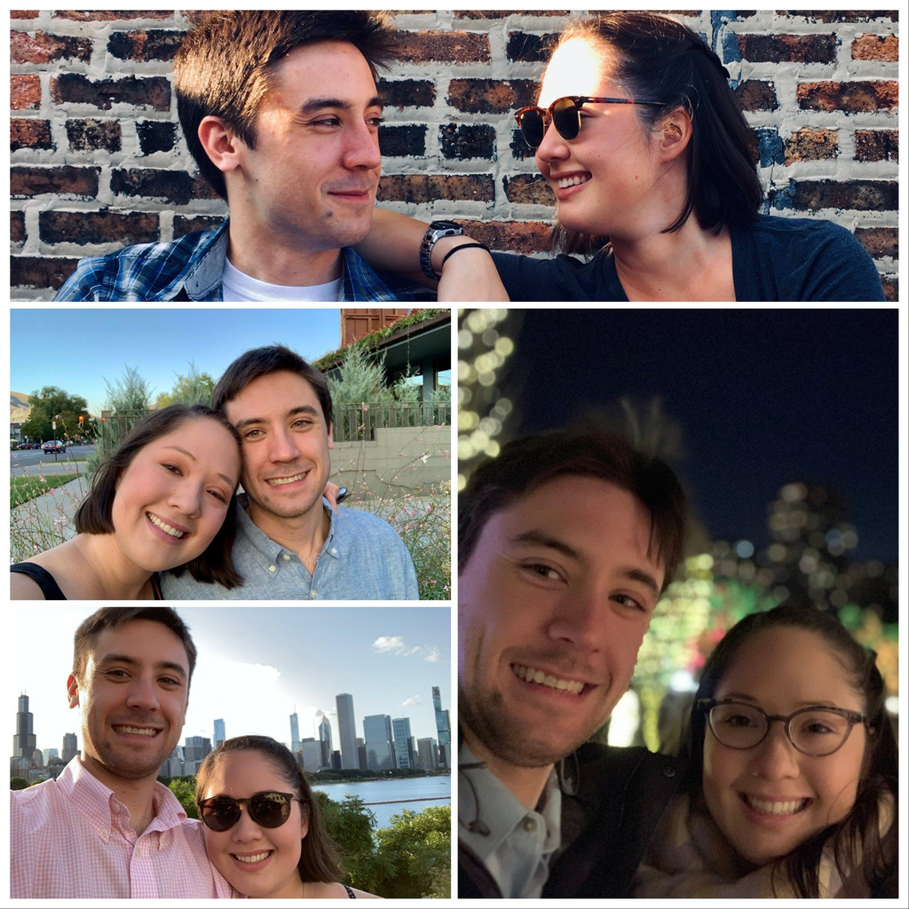

# Lisa and Eric’s Wedding

We hope to celebrate with you in 2022! Since we are in an ongoing pandemic, we recognize a gathering of any size is not without risk and we have a few asks to try to make this as safe an event as possible.

1. All guests must be fully vaccinated and up to date on boosters. For guidance on what that means, please visit [this page](https://www.cdc.gov/coronavirus/2019-ncov/vaccines/stay-up-to-date.html#:~:text=A%20person%20is%20fully%20vaccinated,and%20one%20booster%20when%20eligible).
2. We are asking all guests to take a COVID-19 rapid or at home test on Friday, June 24th. We love you all very much, but please stay home if you test positive or are not feeling well.
3. When inside and not eating or drinking, we ask that guests wear a mask.
4. We very much apologize in advance, but we might need to reduce our guestlist at the last minute. We strongly encourage you to book refundable travel accommodations.

If anything changes, we will update this website and follow up by email. Please check back and provide an email you check regularly with your RSVP.

If you have any questions or feedback, please email us at ericandlisa22@gmail.com.